# WEIGHT LIFTING EXCERCISE DATA ANALYSIS

## SUMMARY

In this paper, several models will be built to fit the Weight Lifting Exercise data. The models will be compared each other and the best performing one will be chosen to make predictions on which class test data belongs to.

The corresponding .Rmd source file with the code used to perform the analysis can be found at the following Github repository: https://github.com/MauroGentile/PracMachineLearning

After an initial preprocessing, data will be split into a training set, representing the 70% of available data, and a validation set representing the remaining 30% of data. A total of 7 different classification models (Random Forest, Knn, C5.0, GBM, Linear, Quadratic and Flexible Discrmininant Analysis) will be then built on the training set and optimized through a 10 folds cross validation.

The several models will be finally compared in terms of:  
1. accuracy, evaluated on the validation set  
2. training time, that is to say, the time needed by each model to train the training set

As a result, it will be shown that Random Forest is the best performing algorithm with a 99.3% accuracy on the validation set, that is to say a 0.7% Out of Sample Error. However Random Forest is also a extremely resource consuming algorithm which took 1 hour and 43 minutes to perform a 10 cross validation training on my iMac 2.7 GHz Core i5 with 8 GB 1600 DDR3 memory.

On the other hand, the algorithm C5.0 reaches nearly the same Out Of Sample error as Random Forest (0.8% vs 0.7%) but it took only 14 minutes to perform the 10 cross validation on the same training set, that is to say, it was 7 time faster than Random Forest.

In other words, RF and C5.0 are nearly indistinguishable models from an accuracy point of view but C5.0 is a much faster algorithm than Random Forest. At least on this data set.

Taking this concept to an extreme, if computing resources or timing is an issue and the training procedure has to be frequently repeated (for instance if the data set gets frequently updated), Knn may become an excellent alternative because while not reaching an accuracy as high as Random Forest, it’s still an excellent model with a superb 96.9% accuracy but taking only 1 minute and a half to train the data, that is to say 70 times lower than Random Forest and nearly 10 times lower than C5.0.

## PRELIMINARY SET-UP

### Loading and preprocessing

Let’s first load the data from the training file and make the introductory manipulations.  
In order we will:  
1. read the data  
2. replace non numeric values with NA’s  
3. exclude the first 7 columns which have nothing to do with the output  
4. exclude those variables with more than 95% of NA values

```r
library(caret)
initialTrainingDataset <- read.csv("pml-training.csv", header = TRUE)
```

```r
suppressWarnings(for (i in 1:(ncol(initialTrainingDataset)-1)) initialTrainingDataset[,i] <- as.numeric(as.character(initialTrainingDataset[,i])))
```

```r
# exclude the first 7 columns
PartiallyCleanedTrainingData <- initialTrainingDataset[,-c(1:7)]

# exclude all columns with more than 95% of NAs values
FinalTrainingData <- PartiallyCleanedTrainingData[, -which(colSums(is.na(PartiallyCleanedTrainingData))/nrow(PartiallyCleanedTrainingData) > 0.95)]
```

### Split in training and validation sets

Training set will be extracted through the function “createDataPartition” in the caret package which will make a “stratified” extraction (i.e. maintaining the output class balance as in the original data set). Since there is a large amount of data available, we can build the models using up to 70% of data while the remaining 30% will be used to evaluate accuracies.

```r
inTrain <- createDataPartition(y = FinalTrainingData$classe, p = 0.7, list= FALSE)
train <- FinalTrainingData[inTrain, ]
validation <- FinalTrainingData[-inTrain, ]
dim(train)
```

```
## [1] 13737    53
```

```r
dim(validation)
```

```
## [1] 5885   53
```

### Class balance check

In classifications problems it is important to check weather classes are balanced.

```r
table(train$classe)
```

```
##
##    A    B    C    D    E
## 3906 2658 2396 2252 2525
```

In this case, while class A is much more populated than the other classes, the imbalance is not cause of concern.

## MODELS BUILDING

In the following several classification models will be applied on training data:  
1. RF: Random forest  
2. LDA: Linear Discriminant Analysis  
3. QDA: Quadratic Discriminant Analysis  
4. FDA: Flexible Discriminant Analysis  
5. GBM: Gradient boosting  
6. KNN: k-nearest neighbors  
7. C5.0: evolution of C4.5

Each model will be automatically optimized through a 10 fold cross validation passed as a parameter to the train function from the caret package (parameters: method=“cv”, number=10).

Center and scale preprocessing will be applied exclusively to LDA, QDA, FDA and Knn since the other models are not sensitive to such preprocessing (refer to “applied predictive modeling”, by Max Kuhn and Kjell Johnson 2013, pg. 550).

Through the function proc.time(), the processing time of each method will be also evaluated and stored for subsequent comparative analysis.

### RANDOM FOREST

```r
set.seed(100)
ptm <- proc.time()
rf <- train(classe ~ ., data = train, method = "rf", prox =
              TRUE, trControl = trainControl(method = "cv",
                                             number = 10))
rf_time<- proc.time() - ptm
```

### LDA

```r
set.seed(100)
ptm <- proc.time()
lda <- train(classe ~ .,data = train,
             method = "lda",
             preProc = c("center","scale"),
             trControl = trainControl(method = "cv", number=10))
LDA_time<- proc.time() - ptm
```

### QDA

```r
set.seed(100)
ptm <- proc.time()
qda <- train(classe ~ ., data = train,
              method = "qda",
              preProc = c("center","scale"),
              trControl = trainControl(method = "cv", number=10))
QDA_time<- proc.time() - ptm
```

### FDA

```r
set.seed(100)
ptm <- proc.time()
fda <- train(classe ~ .,data = train,
             method = "fda",
             preProc = c("center","scale"),
             trControl = trainControl(method = "cv", number=10))
FDA_time<- proc.time() - ptm
```

### GBM

```r
set.seed(100)
ptm <- proc.time()
GBM <- train(classe ~ ., method = "gbm", data = train, trControl = trainControl(method = "cv", number=10))
GBM_time<- proc.time() - ptm
```

### Knn

```r
set.seed(100)
ptm <- proc.time()
knn <- train(classe ~ .,data = train,
             method = "knn",
             preProc = c("center","scale"),
             trControl = trainControl(method = "cv", number=10))
knn_time<- proc.time() - ptm
```

### C5.0

```r
library(C50)
library(plyr)

set.seed(100)
ptm <- proc.time()
c5 <- train(classe ~ .,data = train,
            method = "C5.0",
            trControl = trainControl(method = "cv",
                                     number = 10))
c5_time<- proc.time() - ptm
```

## ACCURACY EVALUATION ON THE VALIDATION SET AND BEST MODEL SELECTION

### Confusion matrix

Confusion matrix for each model will now be calculated on the validation set.

```r
cm_rf <- confusionMatrix(validation$classe, predict(rf, validation))
cm_knn <- confusionMatrix(validation$classe, predict(knn, validation))
cm_c5 <- confusionMatrix(validation$classe, predict(c5, validation))
cm_lda <- confusionMatrix(validation$classe, predict(lda, validation))
cm_qda <- confusionMatrix(validation$classe, predict(qda, validation))
cm_fda <- confusionMatrix(validation$classe, predict(fda, validation))
cm_GBM <- confusionMatrix(validation$classe, predict(GBM, validation))
```

While the graphic comparison of accuracy and confidence intervals of the 7 models will be performed in the next chapter, the tabular version of all these confusion matrices can be found the Appendix 1.

### Plot of accuracies on validation set (which is equivalent to 1-Out of Sample Error)

```r
Models <- data.frame(
                    name=character(),
                    accuracy=numeric(),
                    lower=numeric(),
                    upper=numeric(),
                    system_time=numeric(),
                    user_time=numeric(),
                    elapsed_time=numeric(),
                    stringsAsFactors=FALSE
                    )

Models <- data.frame(name="Random forests", accuracy=cm_rf$overall[1], lower=cm_rf$overall[3], upper=cm_rf$overall[4], elapsed_time=rf_time[3], user_time=rf_time[1]+rf_time[4], system_time=rf_time[2]+rf_time[5])

Models <- rbind(Models, data.frame(name="KNN", accuracy=cm_knn$overall[1], lower=cm_knn$overall[3], upper=cm_knn$overall[4], elapsed_time=knn_time[3], user_time=knn_time[1]+knn_time[4], system_time=knn_time[2]+knn_time[5]))

Models <- rbind(Models, data.frame(name="C5", accuracy=cm_c5$overall[1], lower=cm_c5$overall[3], upper=cm_c5$overall[4], elapsed_time=c5_time[3], user_time=c5_time[1]+c5_time[4], system_time=c5_time[2]+c5_time[5]))

Models <- rbind(Models, data.frame(name="LDA", accuracy=cm_lda$overall[1], lower=cm_lda$overall[3], upper=cm_lda$overall[4], elapsed_time=LDA_time[3], user_time=LDA_time[1]+LDA_time[4], system_time=LDA_time[2]+LDA_time[5]))

Models <- rbind(Models, data.frame(name="QDA", accuracy=cm_qda$overall[1], lower=cm_qda$overall[3], upper=cm_qda$overall[4], elapsed_time=QDA_time[3], user_time=QDA_time[1]+QDA_time[4], system_time=QDA_time[2]+QDA_time[5]))

Models <- rbind(Models, data.frame(name="FDA", accuracy=cm_fda$overall[1], lower=cm_fda$overall[3], upper=cm_fda$overall[4], elapsed_time=FDA_time[3], user_time=FDA_time[1]+FDA_time[4], system_time=FDA_time[2]+FDA_time[5]))

Models <- rbind(Models, data.frame(name="GBM", accuracy=cm_GBM$overall[1], lower=cm_GBM$overall[3], upper=cm_GBM$overall[4], elapsed_time=GBM_time[3], user_time=GBM_time[1]+GBM_time[4], system_time=GBM_time[2]+GBM_time[5]))
```

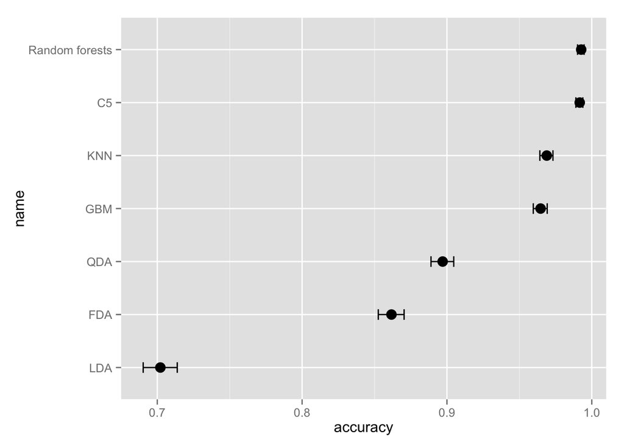

```r
Models <- Models[ order(Models[,2]), ]
ggplot(Models, aes(x=name, y=accuracy)) +
  geom_point(size=4) +
  geom_errorbar(aes(ymin=lower, ymax=upper), width=.2) +
  scale_x_discrete(limits=Models$name)+
  coord_flip()
```

In the above plot, accuracy on the validation set of each method will be displayed together with its confidence interval. The corresponding out of sample error is the complement to 1 of accuracy.

Two methods stand out from the rest and are virtually indistinguishable one other: Random Forest and C5.0 with an accuracy on the validation set of 99.3% and 99.2% respectively that is to say a Out of Sample error of 0.7% and 0.8%. Both models also show a very narrow confidence interval, 0.5% wide.

Other 2 well performing techniques are the Knn and GBM with an accuracy of 96.9% and 96.5% respectively but a wider confidence interval with respect to RF and C5.0.

The discriminant analysis models performance are much worse with accuracies lower than 90%. The LDA is especially poor with an accuracy as low as 70%.

The fact that LDA performs much worse than QDA which in turns performs much worse than Knn confirms that this is a problem with highly non linear decision boundaries among classes.

### Plot of elapsed training time

In the graph below, the training elapsed time of each model will be plotted versus the accuracy, so that in 1 single plot we have both the variables of interest for models comparison and evaluation.

As you can see, Random Forest is an extremely resource consuming algorithm. It took 6212.69 sec to train the data set on my iMac 2.7 GHz Core i5 with 8 GB 1600 DDR3 memory.

C5.0 is therefore a better model than Random Forest at least on this data set since while reaching nearly the same accuracy, it is also much faster.

Stretching this concept to an extreme, depending on how often the user is called to update the model building phase (for instance on data set which may be updated frequently), one may also prefer to use the Knn algorithm instead of C5.0 and Random Forest, because while not reaching the same accuracy (96.9% in the case of Knn, 99.2% in case of C5.0 and 99.3% in case of Random Forest), Knn took only 1 minute and a half to train the data set while Random Forest took 1hr and 43 minutes and C5.0 took 14 minutes to perform the same task on the same dataset.

```r
rf_time
```

```
##    user  system elapsed
## 6105.20   90.95 6212.69
```

```r
c5_time
```

```
##    user  system elapsed
##  858.44    2.01  860.60
```

```r
knn_time
```

```
##    user  system elapsed
##  84.548   4.429  89.565
```

```r
GBM_time
```

```
##    user  system elapsed
##   495.7     3.6   499.7
```

```r
QDA_time
```

```
##    user  system elapsed
##  15.304   2.372  17.716
```

```r
FDA_time
```

```
##    user  system elapsed
##  467.40   10.03  477.88
```

```r
LDA_time
```

```
##    user  system elapsed
##  16.998   2.554  20.225
```

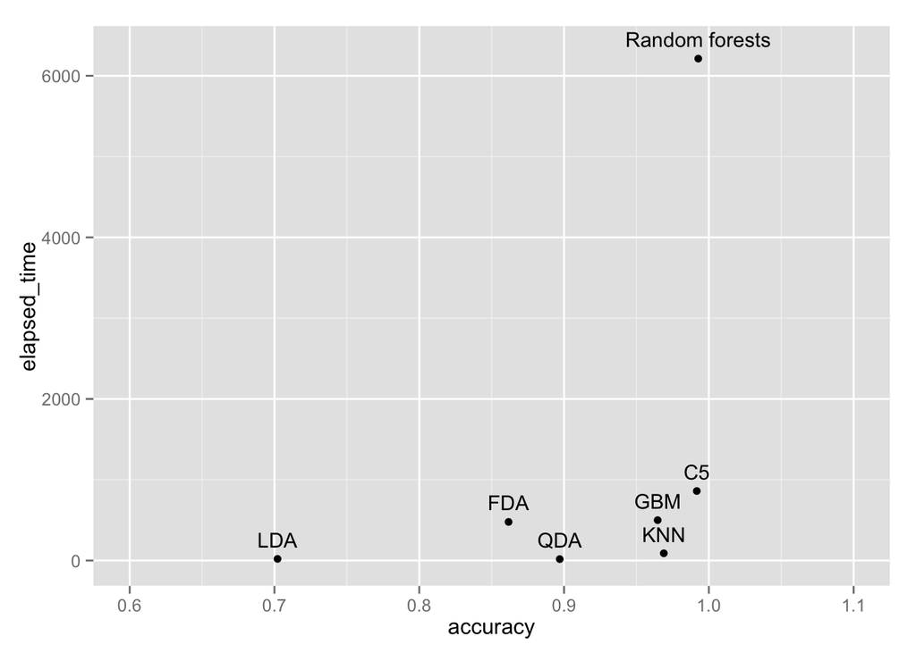

```r
ggplot(Models,aes(x=accuracy, y=elapsed_time)) + geom_point() + geom_text(aes(x=accuracy, label=name), size=4, vjust=-0.8)+ xlim(0.6, 1.1)+ ylim(0, 6300)
```

## PERFORMANCE ON THE TEST DATA

As last step in this project, I would like to compare performance of Random Forest, C5.0 and Knn models, on the 20 row data set provided in the project.

Comparison will be performed both in terms of accuracy and in terms of testing time. Please notice that in this case, the elapsed time being considered is NOT the time to build the model (as above) but the time needed to make 20 predictions using already available models (built above).

This test data will be used only once and, regardless the output, the models built will NOT be changed since otherwise this test set would become part of the training set.

Before running the code, and before seeing the output I anticipate my expectations: if my analysis above is correct, I would expect the RF and C5.0 models giving the exact same output. I would expect also Knn to give the exact same result (Knn accuracy is not as good as C5.0 but it is still very high) even though I would not be surprised for discrepancies.

Finally I would also expect Knn testing time to be much lower than Random Forest and C5.0.

```r
testingData  <- read.csv("pml-testing.csv", header = TRUE)
suppressWarnings(for (i in 1:(ncol(testingData )-1)) testingData [,i] <- as.numeric(as.character(testingData [,i])))

ptm <- proc.time()
test_rf <- predict(rf, newdata = testingData)
rf_test_time<- proc.time() - ptm

ptm <- proc.time()
test_c5 <- predict(c5, newdata = testingData)
c5_test_time<- proc.time() - ptm

ptm <- proc.time()
test_knn <- predict(knn, newdata = testingData)
knn_test_time<- proc.time() - ptm


test_rf
```

```
##  [1] B A B A A E D B A A B C B A E E A B B B
## Levels: A B C D E
```

```r
test_c5
```

```
##  [1] B A B A A E D B A A B C B A E E A B B B
## Levels: A B C D E
```

```r
test_knn
```

```
##  [1] B A B A A B D B A A D C B A E E A B B B
## Levels: A B C D E
```

```r
# Generate the 20 txt files with the 20 predictions to be submitted through the Coursera web page.
# Please notice that these prediction has been generated through c5, i.e. the best model chosen for this data set.

  n = length(test_c5)
  for(i in 1:n){
    filename = paste0("problem_id_",i,".txt")
    write.table(test_c5[i],file=filename,quote=FALSE,row.names=FALSE,col.names=FALSE)
  }
```

Let’s count the output difference between RF/C5.0 and between C5.0/Knn.  
Number of different predicted cases between RF and C5.0:

```r
sum(!(test_rf==test_c5))
```

```
## [1] 0
```

Number of different predicted cases between C5 and Knn:

```r
sum(!(test_knn==test_c5))
```

```
## [1] 2
```

Differences in testing time:

```r
rf_test_time
```

```
##    user  system elapsed
##   7.844   1.915   9.758
```

```r
c5_test_time
```

```
##    user  system elapsed
##   0.153   0.018   0.171
```

```r
knn_test_time
```

```
##    user  system elapsed
##   0.105   0.013   0.118
```

```r
rf_c5_ratio <- rf_test_time[3]/c5_test_time[3]
c5_knn_ratio <-  c5_test_time[3]/knn_test_time[3]
```

C5 was 57.0643 faster than RF in making predictions.  
Knn was 1.4492 faster than C5.0 in making predictions.

As expected, C5.0 and random Forest produced the same exact predictions.

On the other hand, I was a bit surprised to see Knn generating 2 different predictions than those generated by C5.0 and Random Forest. I expected at most 1 discrepancy, if any, given that the 3 models have similar accuracies, and all higher than 96%.

Finally, as expected, Knn was the fastest model to perform the predictions.

## CONCLUSIONS

We have seen that while Random Forest and C5.0 are the best model on this data set and virtually indistinguishable each other with an Out of Sample error of 0.7 and 0.8% respectively, C5.0 takes far less time to train the data set. C5.0 is therefore chosen as preferred model on this data set.

In circumstances where training operation has to performed frequently, Knn may become a excellent alternative if training elapsed time is a concern: giving up for a few points in accuracy, substantial gaining in training and testing processing times can be achieved.

## APPENDIX 1: CONFUSION MATRIX OF EACH OF THE 7 CONSIDERED MODELS

```r
cm_rf
```

```
## Confusion Matrix and Statistics
##
##           Reference
## Prediction    A    B    C    D    E
##          A 1670    4    0    0    0
##          B    5 1133    1    0    0
##          C    0   15 1010    1    0
##          D    0    0   16  948    0
##          E    0    0    0    1 1081
##
## Overall Statistics
##
##                Accuracy : 0.993
##                  95% CI : (0.99, 0.995)
##     No Information Rate : 0.285
##     P-Value [Acc > NIR] : <2e-16
##
##                   Kappa : 0.991
##  Mcnemar's Test P-Value : NA
##
## Statistics by Class:
##
##                      Class: A Class: B Class: C Class: D Class: E
## Sensitivity             0.997    0.984    0.983    0.998    1.000
## Specificity             0.999    0.999    0.997    0.997    1.000
## Pos Pred Value          0.998    0.995    0.984    0.983    0.999
## Neg Pred Value          0.999    0.996    0.997    1.000    1.000
## Prevalence              0.285    0.196    0.175    0.161    0.184
## Detection Rate          0.284    0.193    0.172    0.161    0.184
## Detection Prevalence    0.284    0.194    0.174    0.164    0.184
## Balanced Accuracy       0.998    0.991    0.990    0.997    1.000
```

```r
cm_c5
```

```
## Confusion Matrix and Statistics
##
##           Reference
## Prediction    A    B    C    D    E
##          A 1671    1    1    0    1
##          B    8 1125    5    0    1
##          C    0   12 1006    8    0
##          D    0    2    7  954    1
##          E    0    0    0    2 1080
##
## Overall Statistics
##
##                Accuracy : 0.992
##                  95% CI : (0.989, 0.994)
##     No Information Rate : 0.285
##     P-Value [Acc > NIR] : <2e-16
##
##                   Kappa : 0.989
##  Mcnemar's Test P-Value : NA
##
## Statistics by Class:
##
##                      Class: A Class: B Class: C Class: D Class: E
## Sensitivity             0.995    0.987    0.987    0.990    0.997
## Specificity             0.999    0.997    0.996    0.998    1.000
## Pos Pred Value          0.998    0.988    0.981    0.990    0.998
## Neg Pred Value          0.998    0.997    0.997    0.998    0.999
## Prevalence              0.285    0.194    0.173    0.164    0.184
## Detection Rate          0.284    0.191    0.171    0.162    0.184
## Detection Prevalence    0.284    0.194    0.174    0.164    0.184
## Balanced Accuracy       0.997    0.992    0.992    0.994    0.998
```

```r
cm_knn
```

```
## Confusion Matrix and Statistics
##
##           Reference
## Prediction    A    B    C    D    E
##          A 1645   12    8    5    4
##          B   22 1097   14    6    0
##          C    1   26  982   17    0
##          D    2    0   37  920    5
##          E    2    6   11    5 1058
##
## Overall Statistics
##
##                Accuracy : 0.969
##                  95% CI : (0.964, 0.973)
##     No Information Rate : 0.284
##     P-Value [Acc > NIR] : < 2e-16
##
##                   Kappa : 0.961
##  Mcnemar's Test P-Value : 2.85e-06
##
## Statistics by Class:
##
##                      Class: A Class: B Class: C Class: D Class: E
## Sensitivity             0.984    0.961    0.933    0.965    0.992
## Specificity             0.993    0.991    0.991    0.991    0.995
## Pos Pred Value          0.983    0.963    0.957    0.954    0.978
## Neg Pred Value          0.994    0.991    0.986    0.993    0.998
## Prevalence              0.284    0.194    0.179    0.162    0.181
## Detection Rate          0.280    0.186    0.167    0.156    0.180
## Detection Prevalence    0.284    0.194    0.174    0.164    0.184
## Balanced Accuracy       0.988    0.976    0.962    0.978    0.993
```

```r
cm_lda
```

```
## Confusion Matrix and Statistics
##
##           Reference
## Prediction    A    B    C    D    E
##          A 1367   43  139  117    8
##          B  179  721  132   50   57
##          C   97  100  675  132   22
##          D   68   33  117  696   50
##          E   41  178   85  105  673
##
## Overall Statistics
##
##                Accuracy : 0.702
##                  95% CI : (0.69, 0.714)
##     No Information Rate : 0.298
##     P-Value [Acc > NIR] : <2e-16
##
##                   Kappa : 0.623
##  Mcnemar's Test P-Value : <2e-16
##
## Statistics by Class:
##
##                      Class: A Class: B Class: C Class: D Class: E
## Sensitivity             0.780    0.671    0.588    0.633    0.831
## Specificity             0.926    0.913    0.926    0.944    0.919
## Pos Pred Value          0.817    0.633    0.658    0.722    0.622
## Neg Pred Value          0.909    0.925    0.903    0.918    0.971
## Prevalence              0.298    0.183    0.195    0.187    0.138
## Detection Rate          0.232    0.123    0.115    0.118    0.114
## Detection Prevalence    0.284    0.194    0.174    0.164    0.184
## Balanced Accuracy       0.853    0.792    0.757    0.788    0.875
```

```r
cm_qda
```

```
## Confusion Matrix and Statistics
##
##           Reference
## Prediction    A    B    C    D    E
##          A 1583   68   13    8    2
##          B   84  950   93    5    7
##          C    1   70  940    6    9
##          D    5    1  120  821   17
##          E    0   36   39   22  985
##
## Overall Statistics
##
##                Accuracy : 0.897
##                  95% CI : (0.889, 0.905)
##     No Information Rate : 0.284
##     P-Value [Acc > NIR] : <2e-16
##
##                   Kappa : 0.87
##  Mcnemar's Test P-Value : <2e-16
##
## Statistics by Class:
##
##                      Class: A Class: B Class: C Class: D Class: E
## Sensitivity             0.946    0.844    0.780    0.952    0.966
## Specificity             0.978    0.960    0.982    0.972    0.980
## Pos Pred Value          0.946    0.834    0.916    0.852    0.910
## Neg Pred Value          0.979    0.963    0.945    0.992    0.993
## Prevalence              0.284    0.191    0.205    0.146    0.173
## Detection Rate          0.269    0.161    0.160    0.140    0.167
## Detection Prevalence    0.284    0.194    0.174    0.164    0.184
## Balanced Accuracy       0.962    0.902    0.881    0.962    0.973
```

```r
cm_fda
```

```
## Confusion Matrix and Statistics
##
##           Reference
## Prediction    A    B    C    D    E
##          A 1542   69   40   23    0
##          B   57  944  109   24    5
##          C    0   98  889   37    2
##          D   14   25  108  803   14
##          E    1   74   81   33  893
##
## Overall Statistics
##
##                Accuracy : 0.862
##                  95% CI : (0.853, 0.87)
##     No Information Rate : 0.274
##     P-Value [Acc > NIR] : <2e-16
##
##                   Kappa : 0.825
##  Mcnemar's Test P-Value : <2e-16
##
## Statistics by Class:
##
##                      Class: A Class: B Class: C Class: D Class: E
## Sensitivity             0.955    0.780    0.725    0.873    0.977
## Specificity             0.969    0.958    0.971    0.968    0.962
## Pos Pred Value          0.921    0.829    0.866    0.833    0.825
## Neg Pred Value          0.983    0.944    0.930    0.976    0.996
## Prevalence              0.274    0.206    0.208    0.156    0.155
## Detection Rate          0.262    0.160    0.151    0.136    0.152
## Detection Prevalence    0.284    0.194    0.174    0.164    0.184
## Balanced Accuracy       0.962    0.869    0.848    0.920    0.970
```

```r
cm_GBM
```

```
## Confusion Matrix and Statistics
##
##           Reference
## Prediction    A    B    C    D    E
##          A 1650   12    6    4    2
##          B   22 1081   33    3    0
##          C    0   37  972   17    0
##          D    1    5   31  918    9
##          E    1   10    6    9 1056
##
## Overall Statistics
##
##                Accuracy : 0.965
##                  95% CI : (0.96, 0.969)
##     No Information Rate : 0.284
##     P-Value [Acc > NIR] : < 2e-16
##
##                   Kappa : 0.955
##  Mcnemar's Test P-Value : 0.000418
##
## Statistics by Class:
##
##                      Class: A Class: B Class: C Class: D Class: E
## Sensitivity             0.986    0.944    0.927    0.965    0.990
## Specificity             0.994    0.988    0.989    0.991    0.995
## Pos Pred Value          0.986    0.949    0.947    0.952    0.976
## Neg Pred Value          0.994    0.987    0.984    0.993    0.998
## Prevalence              0.284    0.195    0.178    0.162    0.181
## Detection Rate          0.280    0.184    0.165    0.156    0.179
## Detection Prevalence    0.284    0.194    0.174    0.164    0.184
## Balanced Accuracy       0.990    0.966    0.958    0.978    0.992
```